# Effect of Major Historical Events on S&P500 Index

2024-03-27

# Team Neo Midterm Project

Terminology in Trading

- “open” - The opening price for the specified date(s).
- “close” - The closing price for the specified date(s).
- “high” - The high price for the specified date(s).
- “low” - The low price for the specified date(s).
- “volume” - The volume for the specified date(s).
- “change” - The price change since the previous trading weekly close. (For monthly take previous trading month’s close and for daily take previous trading day’s close.)

We are analyzing how major historical events impacted the S&P 500 index using daily data in last 20 years, that is from 2003-2023. Specifically, we will:

1. Examine the daily closing prices of the index to see how events affected the price levels.
2. Calculate and analyze the daily returns and standardized daily returns to understand volatility around events.
3. Study the correlation between different variables in the dataset to identify relationships.
4. Plot the daily returns, standardized returns, and closing prices around major events to visualize the impacts.
5. Remove outliers from the data and re-analyze to ensure robustness of our findings.

By looking at prices, returns, correlations, visualizations, and handling outliers, we aim to comprehensively assess how significant historical occurrences influenced the behavior of the S&P 500 index over this 20-year period.

```r
df <- data.frame(read.csv('dataset2003-2023.csv'))
df$Date <- as.Date(df$Date)
str(df)
```

```
## 'data.frame':    5285 obs. of  7 variables:
##  $ Date     : Date, format: "2003-01-02" "2003-01-03" ...
##  $ Open     : num  880 909 909 929 923 ...
##  $ High     : num  909 911 932 931 923 ...
##  $ Low      : num  880 903 909 920 908 ...
##  $ Close    : num  909 909 929 923 910 ...
##  $ Adj.Close: num  909 909 929 923 910 ...
##  $ Volume   : num  1.23e+09 1.13e+09 1.44e+09 1.55e+09 1.47e+09 ...
```

```r
new_df <- subset(df, select = -c(6))
str(new_df)
```

```
## 'data.frame':    5285 obs. of  6 variables:
##  $ Date  : Date, format: "2003-01-02" "2003-01-03" ...
##  $ Open  : num  880 909 909 929 923 ...
##  $ High  : num  909 911 932 931 923 ...
##  $ Low   : num  880 903 909 920 908 ...
##  $ Close : num  909 909 929 923 910 ...
##  $ Volume: num  1.23e+09 1.13e+09 1.44e+09 1.55e+09 1.47e+09 ...
```

```r
summary(new_df)
```

```
##       Date                 Open           High           Low
##  Min.   :2003-01-02   Min.   : 679   Min.   : 695   Min.   : 667
##  1st Qu.:2008-04-03   1st Qu.:1226   1st Qu.:1234   1st Qu.:1219
##  Median :2013-07-02   Median :1649   Median :1656   Median :1639
##  Mean   :2013-07-01   Mean   :2082   Mean   :2094   Mean   :2070
##  3rd Qu.:2018-09-28   3rd Qu.:2752   3rd Qu.:2764   3rd Qu.:2734
##  Max.   :2023-12-29   Max.   :4805   Max.   :4819   Max.   :4781
##      Close          Volume
##  Min.   : 677   Min.   :3.56e+08
##  1st Qu.:1226   1st Qu.:2.88e+09
##  Median :1650   Median :3.61e+09
##  Mean   :2083   Mean   :3.63e+09
##  3rd Qu.:2749   3rd Qu.:4.28e+09
##  Max.   :4797   Max.   :1.15e+10
```

```r
num_variables <- subset(new_df,select = -c(1))
head(num_variables)
```

```
##   Open High Low Close   Volume
## 1  880  909 880   909 1.23e+09
## 2  909  911 903   909 1.13e+09
## 3  909  932 909   929 1.44e+09
## 4  929  931 920   923 1.55e+09
## 5  923  923 908   910 1.47e+09
## 6  910  928 910   928 1.56e+09
```

First we change the data type for date column as Date. Further we drop adjusted close column as we already had similar column named close and we wanted to work with the raw data.

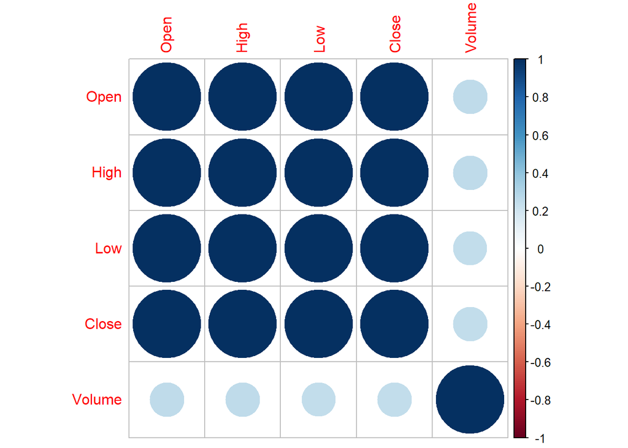

```r
corr_matrix <- cor(num_variables)
corrplot(corr_matrix)
```

```r
corr_matrix
```

```
##        Open  High   Low Close Volume
## Open   1.00 1.000 1.000 1.000  0.250
## High   1.00 1.000 1.000 1.000  0.253
## Low    1.00 1.000 1.000 1.000  0.245
## Close  1.00 1.000 1.000 1.000  0.249
## Volume 0.25 0.253 0.245 0.249  1.000
```

The correlation plot shows that we have weak positive correlation of open high low and close variables with Volume variable. From the correlation matrix, we can see that the closing price is highly correlated with the high price and low price. This is expected as the all of these prices are related to each other. For example,

- The closing price is correlated to opening price.
- The highest and lowest prices are correlated to the opening and closing prices.

```r
new_df$daily_change <- (new_df$Close / lag(new_df$Close) - 1) * 100

head(new_df)
```

```
##         Date Open High Low Close   Volume daily_change
## 1 2003-01-02  880  909 880   909 1.23e+09           NA
## 2 2003-01-03  909  911 903   909 1.13e+09      -0.0484
## 3 2003-01-06  909  932 909   929 1.44e+09       2.2474
## 4 2003-01-07  929  931 920   923 1.55e+09      -0.6545
## 5 2003-01-08  923  923 908   910 1.47e+09      -1.4086
## 6 2003-01-09  910  928 910   928 1.56e+09       1.9386
```

The code computes the daily returns for the S&P 500 index. The daily returns are calculated as the percentage change in the closing price from the previous day. We will use these daily returns to analyze the volatility of the index around major events.

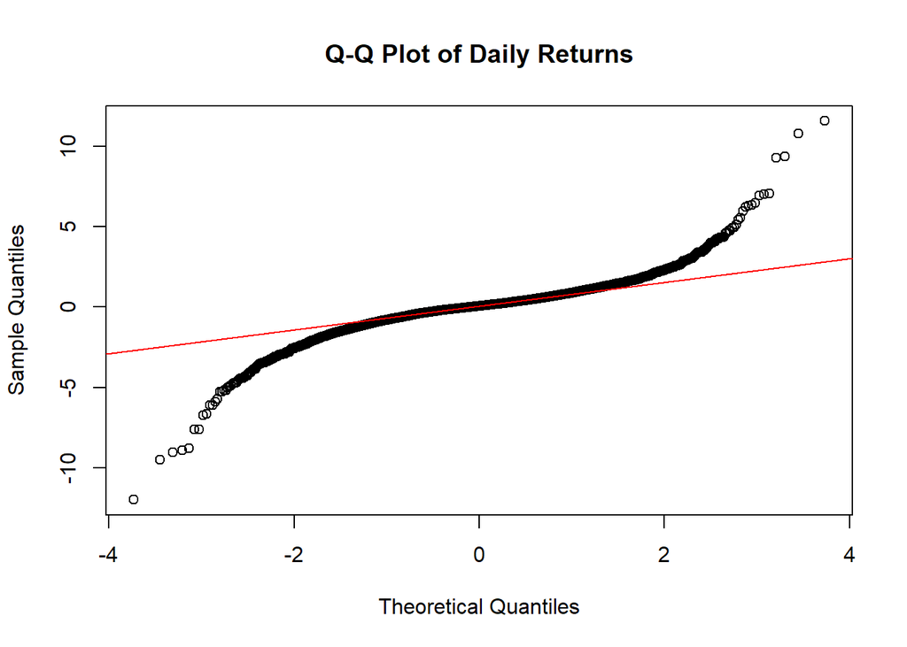

```r
new_df2 <- na.omit(new_df)

qqnorm(new_df2$daily_change, main = "Q-Q Plot of Daily Returns")
qqline(new_df2$daily_change, col = "red") # Add reference line
```

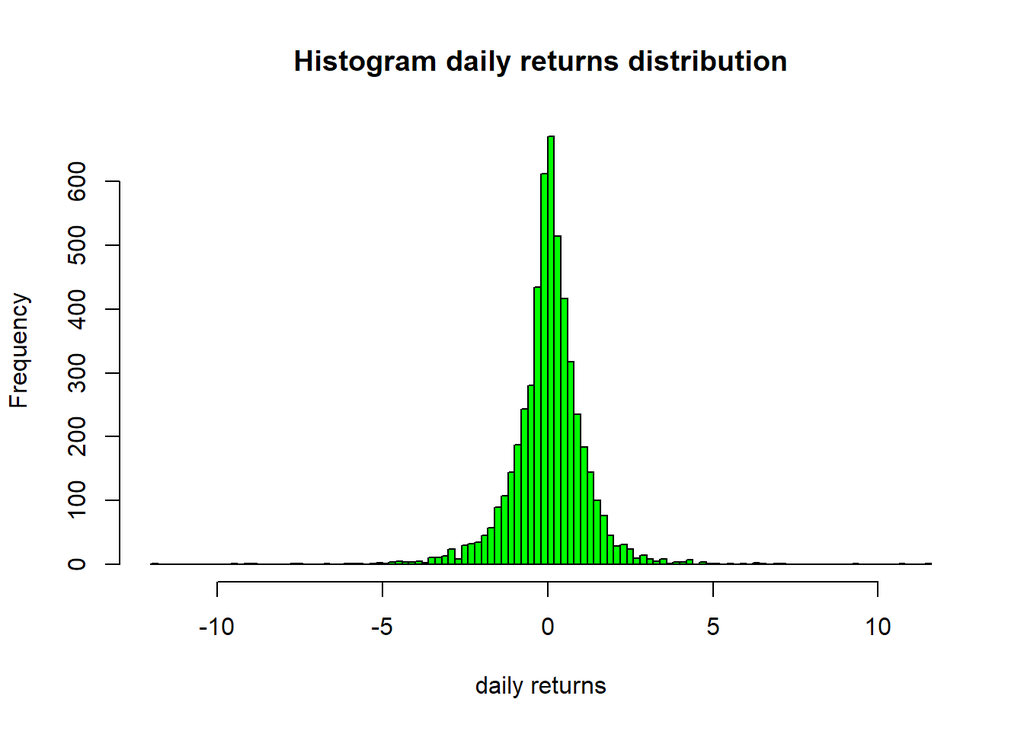

```r
# hist(new_df2$daily_change_standardized, breaks = 50, col = 'green', main = "Histogram daily returns standardized distribution",xlab = "daily returns")
hist(new_df2$daily_change, breaks = 100, col = 'green', main = "Histogram daily returns distribution",xlab = "daily returns")
```

The significance of this output lies in visualizing the distribution of daily percentage changes in the S&P 500 index. The histogram provides insights into the frequency and magnitude of daily returns, allowing us to assess the volatility, risk, and potential patterns in the stock market. Green color is used for the bars in the histogram, but you can modify the color (col) parameter to any other color if desired.

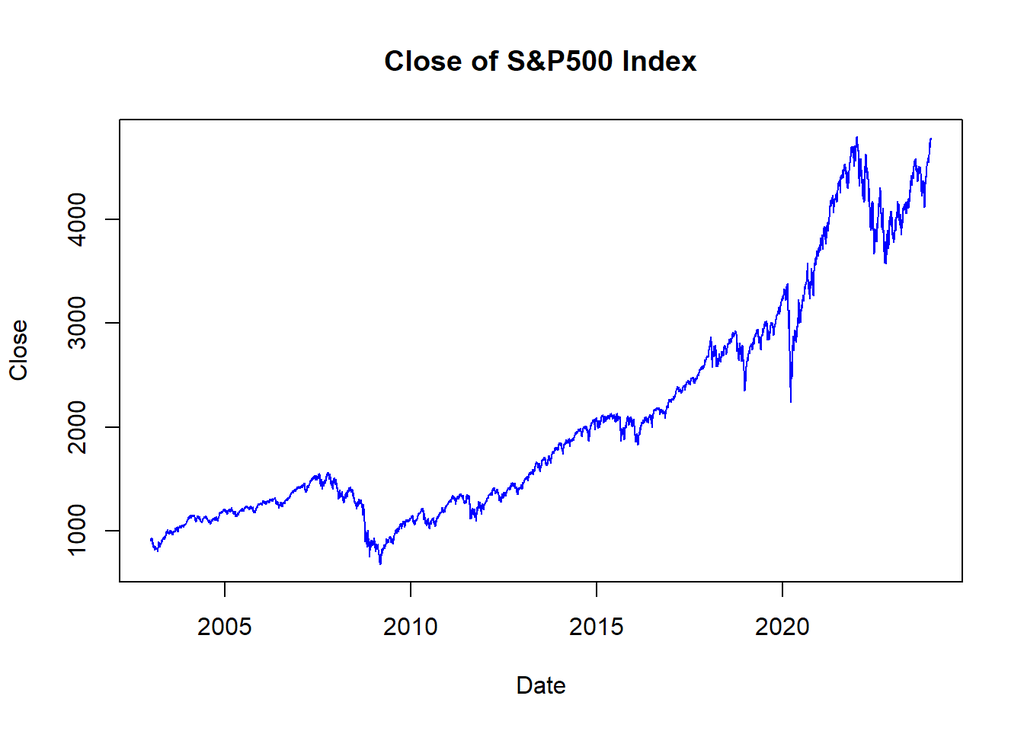

```r
plot(new_df2$Date, new_df2$Close, type = "l", col = "blue", xlab = "Date", ylab = "Close", main = "Close of S&P500 Index")
```

The graph visually represent the historical trend of the S&P 500 index closing values over time. By plotting the data as a line graph, I can observe the overall direction of the index (whether it’s trending upwards, downwards, or relatively stable) and identify periods of significant movement or volatility.

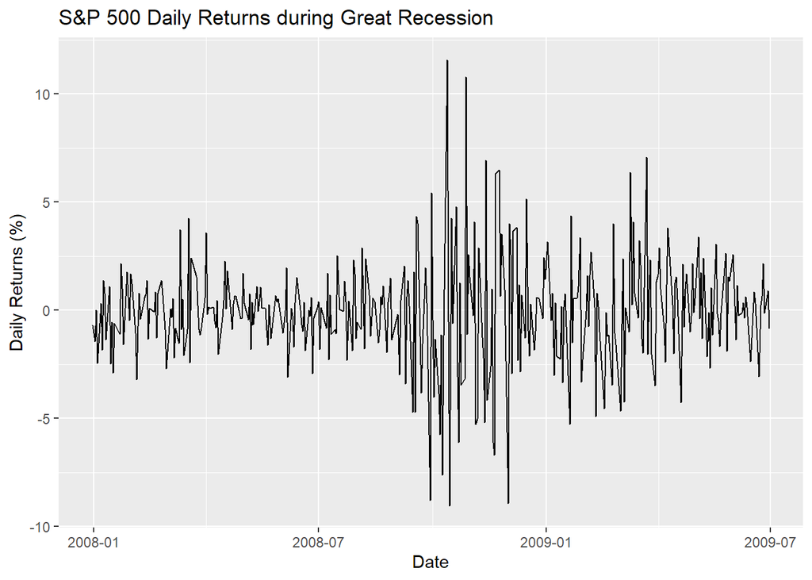

```r
# Define the event windows
great_recession_start <- as.Date("2007-12-31")
great_recession_end <- as.Date("2009-06-30")

covid_start <- as.Date("2020-02-03")
lockdown_end <- as.Date("2020-08-31")
covid_end <- as.Date("2023-05-11")

russia_ukraine_start <- as.Date("2022-02-24")
russia_ukraine_end <- Sys.Date()  # Current date

# Subset the data for each event window
great_recession_data <- new_df2 %>%
  filter(Date >= great_recession_start & Date <= great_recession_end)

covid_data <- new_df %>%
  filter(Date >= covid_start & Date <= covid_end)

russia_ukraine_data <- new_df2 %>%
  filter(Date >= russia_ukraine_start & Date <= russia_ukraine_end)

# Visualize daily returns for each event
ggplot(great_recession_data, aes(x = Date, y = daily_change)) +
  geom_line() +
  xlab("Date") +
  ylab("Daily Returns (%)") +
  ggtitle("S&P 500 Daily Returns during Great Recession")
```

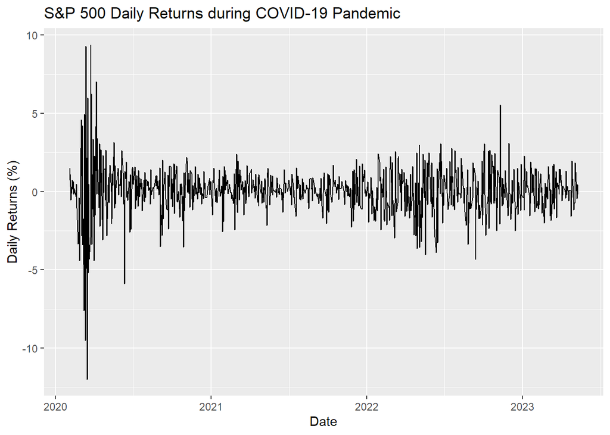

```r
ggplot(covid_data, aes(x = Date, y = daily_change)) +
  geom_line() +
  xlab("Date") +
  ylab("Daily Returns (%)") +
  ggtitle("S&P 500 Daily Returns during COVID-19 Pandemic")
```

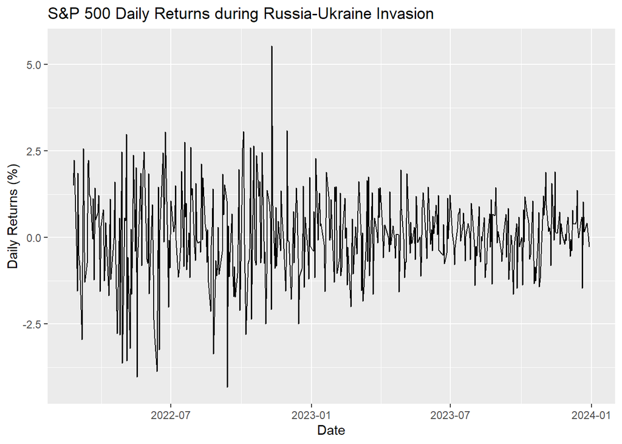

```r
ggplot(russia_ukraine_data, aes(x = Date, y = daily_change)) +
  geom_line() +
  xlab("Date") +
  ylab("Daily Returns (%)") +
  ggtitle("S&P 500 Daily Returns during Russia-Ukraine Invasion")
```

```r
# Defining a function to compute summary statistics
compute_summary <- function(data) {
  data %>%
    summarize(mean_return = mean(daily_change, na.rm = TRUE),
              median_return = median(daily_change, na.rm = TRUE),
              max_return = max(daily_change, na.rm = TRUE),
              min_return = min(daily_change, na.rm = TRUE))
}

# Apply the function to each event data
great_recession_summary <- compute_summary(great_recession_data)
covid_summary <- compute_summary(covid_data)
russia_ukraine_summary <- compute_summary(russia_ukraine_data)
```

The above code calculates the daily returns for the S&P 500 index during the Great Recession, COVID-19 pandemic, and Russia-Ukraine invasion. The daily returns are calculated as the percentage change in the closing price from the previous day. We then visualize the daily returns for each event using line plots(time period is different for each of these events, so we drew separate graphs) and compute summary statistics to understand the volatility of the index around these events.

The COVID-19 Virus end date used is the one officially declared by the [cdc.gov](https://www.cdc.gov/coronavirus/2019-ncov/your-health/end-of-phe.html)

```r
sd(great_recession_data$daily_change, na.rm=TRUE)
```

```
## [1] 2.46
```

```r
sd(covid_data$daily_change, na.rm=TRUE)
```

```
## [1] 1.56
```

```r
sd(russia_ukraine_data$daily_change, na.rm = TRUE)
```

```
## [1] 1.22
```

Here we calculate the standard deviation of daily returns for each event to measure the volatility of the S&P 500 index around these events. The standard deviation provides a measure of the dispersion or variability of the daily returns, allowing us to assess the risk and potential impact of these events on the stock market. As we see in the above graphs and the standard deviation values, the volatility of the S&P 500 index was highest during the Great Recession, followed by the COVID-19 pandemic and the Russia-Ukraine invasion.

```r
# Subset the data for the specified periods
pre_recession <- new_df2 %>%
  filter(Date >= as.Date("2003-01-01") & Date <= (great_recession_start - days(1)))

during_recession <- new_df2 %>%
  filter(Date >= great_recession_start & Date <= great_recession_end)

post_recession <- new_df2 %>%
  filter(Date >= (great_recession_end + days(1)) & Date <= as.Date("2019-12-31"))

# Define a function to calculate yearly returns
calculate_yearly_returns <- function(data) {
  data %>%
    mutate(Year = format(Date, "%Y")) %>%
    group_by(Year) %>%
    summarize(start_price = first(Close),
              end_price = last(Close),
              yearly_return = (end_price - start_price) / start_price * 100)
}

# Apply the function to each period data
pre_recession_yearly_returns <- calculate_yearly_returns(pre_recession)
during_recession_yearly_returns <- calculate_yearly_returns(during_recession)
post_recession_yearly_returns <- calculate_yearly_returns(post_recession)

# Compare summary statistics (e.g., mean yearly returns)
mean(pre_recession_yearly_returns$yearly_return)
```

```
## [1] 10.3
```

```r
mean(during_recession_yearly_returns$yearly_return)
```

```
## [1] -13
```

```r
mean(post_recession_yearly_returns$yearly_return)
```

```
## [1] 12
```

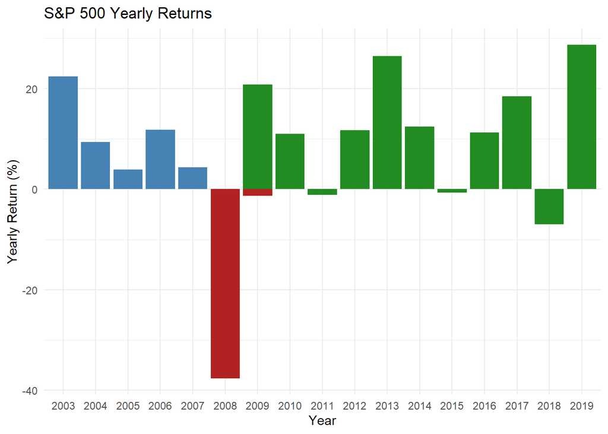

```r
# Visualize yearly returns
ggplot() +
  geom_bar(data = pre_recession_yearly_returns, aes(x = Year, y = yearly_return), stat = "identity", fill = "steelblue") +
  geom_bar(data = during_recession_yearly_returns, aes(x = Year, y = yearly_return), stat = "identity", fill = "firebrick") +
  geom_bar(data = post_recession_yearly_returns, aes(x = Year, y = yearly_return), stat = "identity", fill = "forestgreen") +
  xlab("Year") +
  ylab("Yearly Return (%)") +
  ggtitle("S&P 500 Yearly Returns") +
  scale_x_discrete(limits = unique(c(pre_recession_yearly_returns$Year, during_recession_yearly_returns$Year, post_recession_yearly_returns$Year))) +
  theme_minimal()
```

The code calculates the yearly returns for the S&P 500 index before, during, and after the Great Recession. The yearly returns are calculated as the percentage change in the closing price from the beginning to the end of each year. We then compare the mean yearly returns for each period and visualize the yearly returns using bar plots to understand the performance of the index around the Great Recession.

```r
# Link used for considering the virus progression end date: https://www.defense.gov/Spotlights/Coronavirus-DOD-Response/Timeline/
# Subset the data for the specified periods
pre_pandemic <- new_df2 %>%
  filter(Date >= as.Date("2009-07-01") & Date <= as.Date("2019-12-31"))

#covid_pandemic <- new_df2 %>%
 # filter(Date >= as.Date("2020-01-01") & Date <= as.Date("2022-05-31"))

covid_pandemic <- covid_data

post_pandemic <- new_df2 %>%
  filter(Date >= covid_end & Date <= Sys.Date())

# Apply the function to each period data
pre_pandemic_yearly_returns <- calculate_yearly_returns(pre_pandemic)
covid_pandemic_yearly_returns <- calculate_yearly_returns(covid_pandemic)
post_pandemic_yearly_returns <- calculate_yearly_returns(post_pandemic)


# Compare summary statistics (e.g., mean yearly returns)
mean(post_pandemic_yearly_returns$yearly_return)
```

```
## [1] 15.5
```

```r
mean(covid_pandemic_yearly_returns$yearly_return)
```

```
## [1] 8.12
```

```r
mean(post_pandemic_yearly_returns$yearly_return)
```

```
## [1] 15.5
```

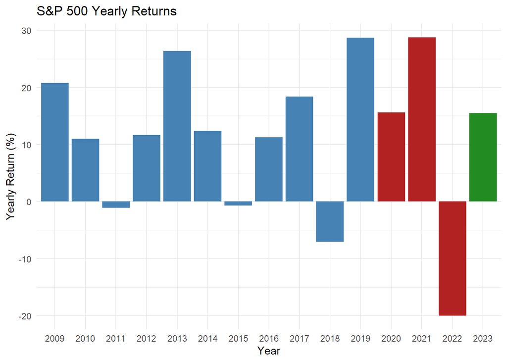

```r
# Visualize yearly returns
ggplot() +
  geom_bar(data = pre_pandemic_yearly_returns, aes(x = Year, y = yearly_return), stat = "identity", fill = "steelblue") +
  geom_bar(data = covid_pandemic_yearly_returns, aes(x = Year, y = yearly_return), stat = "identity", fill = "firebrick") +
  geom_bar(data = post_pandemic_yearly_returns, aes(x = Year, y = yearly_return), stat = "identity", fill = "forestgreen") +
  xlab("Year") +
  ylab("Yearly Return (%)") +
  ggtitle("S&P 500 Yearly Returns") +
  scale_x_discrete(limits = unique(c(pre_pandemic_yearly_returns$Year, covid_pandemic_yearly_returns$Year, post_pandemic_yearly_returns$Year))) +
  theme_minimal()
```

Considering the lockdown end date as a starting point for the pre-Russia-Ukraine invasion period.

Furthermore we calculate the yearly returns for the S&P 500 index before, during, and after the COVID-19 pandemic. The yearly returns are calculated as the percentage change in the closing price from the beginning to the end of each year. We then compare the mean yearly returns for each period and visualize the yearly returns using bar plots(similar to the above plot) to understand the performance of the index around the COVID-19 pandemic.

## Q1 What patterns emerge in financial markets, particularly in the S&P500 Index when confronted with significant events such as the Great Recession, the COVID-19 pandemic, and the Russia-Ukraine Invasion?

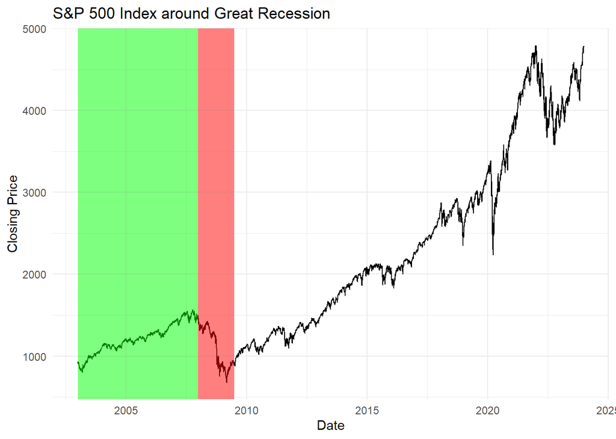

```r
# Define event periods
before_gr <- pre_recession

during_gr <- during_recession

# Line plot with shaded regions
ggplot(new_df2, aes(x = Date, y = Close)) +
  geom_line() +
  geom_rect(data = during_gr,
            aes(xmin = min(Date), xmax = max(Date), ymin = -Inf, ymax = Inf),
            fill = "red", alpha = 0.002) +
  geom_rect(data = before_gr,
            aes(xmin = min(Date), xmax = max(Date), ymin = -Inf, ymax = Inf),
            fill = "green", alpha = 0.002) +
  labs(title = "S&P 500 Index around Great Recession",
       x = "Date",
       y = "Closing Price") +
  theme_minimal()
```

The above code creates a line plot of the S&P 500 index closing prices and shades the regions corresponding to the periods before and during the Great Recession. This visualization allows us to compare the index’s performance before and after the start of the Great Recession, providing insights into the impact of the event on the stock market. we observe that the index experienced a significant decline during the Great Recession, followed by a recovery period. the few reasons for the decline could be the housing market crash, the financial crisis, and the subsequent economic downturn.

```r
# Calculating the recovery period for the Great Recession

gr_lowest_point <- min(great_recession_data$Close)
gr_lowest_point_date <- great_recession_data$Date[great_recession_data$Close == gr_lowest_point]
gr_initial_level <- new_df2$Close[new_df2$Date == great_recession_start]
gr_recovery_date <- min(new_df2$Date[new_df2$Close >= gr_initial_level & new_df2$Date > great_recession_start])


gr_recovery_duration <- gr_recovery_date - gr_lowest_point_date

print(gr_recovery_duration)
```

```
## Time difference of 1403 days
```

The recovery period for the S&P500 Index from it’s lowest during the Great Recession to the point where it reached the initial level was 1403 days.

we calculated the recovery period for the S&P 500 index from its lowest point during the Great Recession to the point where it reached the initial level. The recovery period is defined as the number of days it took for the index to recover from the lowest point to the initial level. This provides insights into the duration and speed of recovery following a significant decline in the stock market.

```r
# Calculating the recovery period for the Great Recession

covid_lowest_point <- min(covid_data$Close)
covid_lowest_point_date <- covid_data$Date[covid_data$Close == covid_lowest_point]
covid_initial_level <- new_df2$Close[new_df2$Date == covid_start]
covid_recovery_date <- min(new_df2$Date[new_df2$Close >= covid_initial_level & new_df2$Date > covid_lowest_point_date])

covid_recovery_duration <- covid_recovery_date - covid_lowest_point_date

print(covid_recovery_duration)
```

```
## Time difference of 119 days
```

The recovery period for the SandP500 Index from it’s lowest during COVID-19 pandemic to the point where it reached the initial level was 119 days.

We calculated the recovery period for the S&P 500 index from its lowest point during the COVID-19 pandemic to the point where it reached the recovery level. Similarly the recovery period is defined in days it took for the index to recover from the lowest point to the initial level. This provides insights into the duration and speed of recovery following a significant decline in the stock market. however the calculated recovery period shows that the stock market recovery from covid happenned much faster than the great recession. we will see this in the graph

```r
# Calculating the recovery period for the Great Recession

ruw_lowest_point <- min(russia_ukraine_data$Close)
ruw_lowest_point_date <- russia_ukraine_data$Date[russia_ukraine_data$Close == ruw_lowest_point]
ruw_initial_level <- new_df2$Close[new_df2$Date == russia_ukraine_start]
ruw_recovery_date <- min(new_df2$Date[new_df2$Close >= ruw_initial_level & new_df2$Date > ruw_lowest_point_date])

ruw_recovery_duration <- ruw_recovery_date - ruw_lowest_point_date

print(ruw_recovery_duration)
```

```
## Time difference of 239 days
```

The Russia Ukraine invasion recovery period was calculated in the same way as the above two events. The recovery period is defined as the number of days it took for the index to recover from the lowest point to the initial level. The calculated recovery period shows that the stock market recovery from Russia Ukraine invasion was faster than the great recession but slower than the covid-19 pandemic. However since the War is still ongoing, the recovery period might change in the future.

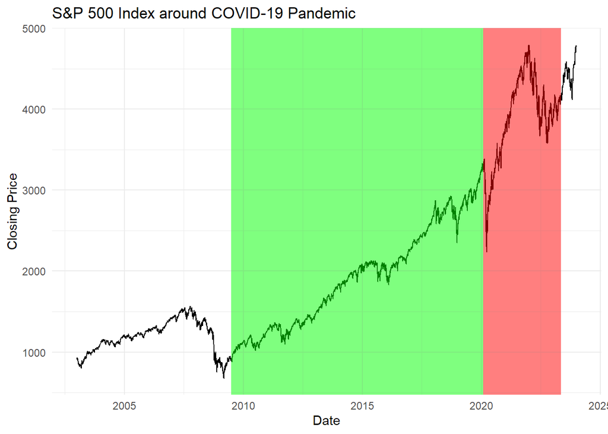

```r
# Define event periods
before_covid <- new_df2 %>%
  filter(Date >= great_recession_end + days(1) & Date <= covid_start - days(1))

during_covid <- covid_data

after_covid <- new_df2 %>%
  filter(Date >= as.Date("2022-06-01") & Date <= Sys.Date())

# Line plot with shaded regions
ggplot(new_df2, aes(x = Date, y = Close)) +
  geom_line() +
  geom_rect(data = during_covid,
            aes(xmin = min(Date), xmax = max(Date), ymin = -Inf, ymax = Inf),
            fill = "red", alpha = 0.002) +
  geom_rect(data = before_covid,
            aes(xmin = min(Date), xmax = max(Date), ymin = -Inf, ymax = Inf),
            fill = "green", alpha = 0.002) +
  labs(title = "S&P 500 Index around COVID-19 Pandemic",
       x = "Date",
       y = "Closing Price") +
  theme_minimal()
```

The above code creates a line plot of the S&P 500 index closing prices corresponding to the periods before and during the COVID-19 pandemic. This visualization allows us to compare the index’s performance before and after the start of the COVID-19 pandemic, providing insights into the impact of the event on the stock market. we observe that the index experienced a significant decline during the COVID-19 pandemic, followed by a recovery period. the few reasons for the decline could be the lockdowns, travel restrictions, and the subsequent economic downturn.

However the covid pandemic did not have a long lasting effect on the stock market as the recovery period was much faster than the great recession unlike expectations.the main reason was the federal government’s intervention in the economy and the stock market. low interest rates(close to 0) and the stimulus packages helped the stock market recover faster than expected. - Please refer the below link for more information on the stock market recovery from covid-19 pandemic - reference: https://www.wsj.com/articles/the-s-p-500-sets-first-record-since-february-erasing-its-coronavirus-plunge-11597781130

```r
# Calculating the recovery period for the COVID-19 Pandemic

covid_lowest_point <- min(covid_data$Close)
covid_lowest_point_date <- covid_data$Date[covid_data$Close == covid_lowest_point]
covid_initial_level <- new_df2$Close[new_df2$Date == covid_start]
covid_recovery_date <- min(new_df2$Date[new_df2$Close >= covid_initial_level & new_df2$Date > covid_lowest_point_date])

covid_recovery_duration <- covid_recovery_date - covid_lowest_point_date

print(covid_recovery_duration)
```

```
## Time difference of 119 days
```

```r
# Calculating the recovery period for the COVID-19 Pandemic

covid_lowest_point <- min(covid_data$Close)
covid_lowest_point_date <- covid_data$Date[covid_data$Close == covid_lowest_point]
covid_initial_level <- new_df2$Close[new_df2$Date == covid_start]
covid_recovery_date <- min(new_df2$Date[new_df2$Close >= covid_initial_level & new_df2$Date > covid_lowest_point_date])

covid_recovery_duration <- covid_recovery_date - covid_lowest_point_date

print(covid_recovery_duration)
```

```
## Time difference of 119 days
```

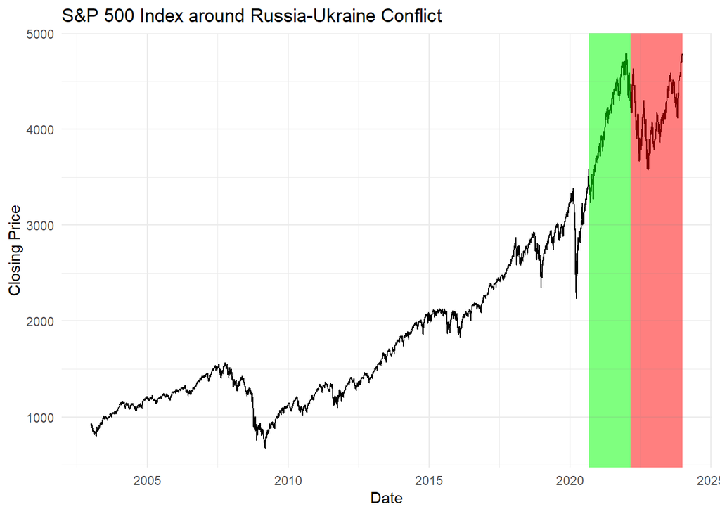

```r
# Create a line plot with shaded regions
ggplot(new_df2, aes(x = Date, y = Close)) +
  geom_line() +
  geom_rect(data = russia_ukraine_data,
            aes(xmin = min(Date), xmax = max(Date), ymin = -Inf, ymax = Inf),
            fill = "red", alpha = 0.002) +
  geom_rect(data = subset(new_df2, Date >= lockdown_end & Date <= russia_ukraine_start - days(1)),
            aes(xmin = min(Date), xmax = max(Date), ymin = -Inf, ymax = Inf),
            fill = "green", alpha = 0.002) +
  labs(title = "S&P 500 Index around Russia-Ukraine Conflict",
       x = "Date",
       y = "Closing Price") +
  theme_minimal()
```

Similar to covid pandemic, the above code creates a line plot of the S&P 500 index closing prices corresponding to the periods before and during the Russia-Ukraine conflict. This visualization allows us to compare the index’s performance before and after the start of the Russia-Ukraine conflict, providing insights into the impact of the event on the stock market. we observe that the index experienced a significant decline during the Russia-Ukraine conflict, followed by a recovery period. the few reasons for the decline could be the war, sanctions, and the subsequent economic downturn.

```r
# Calculating the recovery period for Russia Ukraine Invasion

ruw_lowest_point <- min(russia_ukraine_data$Close)
ruw_lowest_point_date <- russia_ukraine_data$Date[russia_ukraine_data$Close == ruw_lowest_point]
ruw_initial_level <- new_df2$Close[new_df2$Date == russia_ukraine_start]
ruw_recovery_date <- min(new_df2$Date[new_df2$Close >= ruw_initial_level & new_df2$Date > ruw_lowest_point_date])

ruw_recovery_duration <- ruw_recovery_date - ruw_lowest_point_date

print(ruw_recovery_duration)
```

```
## Time difference of 239 days
```

## Q2 How is the S&P500 Index affected by the Great Recession?

```r
new_after_gr <- subset(new_df2, Date <= '2012-12-31'  & Date >= '2008-01-01')
new_before_gr <- subset(new_df2, Date <= '2007-12-31'  & Date >= '2003-01-01')

t_test_GR = t.test(new_before_gr$Close,new_after_gr$Close)

t_test_GR
```

```
##
##  Welch Two Sample t-test
##
## data:  new_before_gr$Close and new_after_gr$Close
## t = 4, df = 2514, p-value = 1e-04
## alternative hypothesis: true difference in means is not equal to 0
## 95 percent confidence interval:
##  13.3 41.4
## sample estimates:
## mean of x mean of y
##      1218      1191
```

The above code calculates the two sample t-test for the S&P 500 index closing prices before and after the Great Recession. The t-test is used to compare the means of two groups and determine if there is a statistically significant difference between them. In this case, we are comparing the mean closing prices before and after the Great Recession to assess the impact of the event on the stock market. The t-test results provide insights into the significance of the difference in mean closing prices and help us understand the impact of the Great Recession on the stock market.

We can conclude that there is strong evidence to reject the null hypothesis as the p values is less than the level of significance 0.05. The test indicates a statistically significant difference in the means of the S&P 500 index closing values before and after the specified periods. The results are as expected that is before GR the mean was higher compared to the mean after GR and the main reason behind it is the number of days market took for recovery that is 1403 days.

In simpler terms, the analysis suggests that there was a statistically significant change in the average closing values of the S&P 500 index before and after the specified time periods, with the mean values differing by a notable amount.

## Q3 How is the S&P500 Index affected by the COVID-19 pandemic?

```r
new_before_covid <- subset(new_df2, Date <= '2019-12-31'  & Date >= '2016-06-01')
new_after_covid <- subset(new_df2, Date < '2023-05-11'  & Date >= '2020-01-01')

t_test_covid = t.test(new_before_covid$Close,new_after_covid$Close, na.rm= TRUE)
t_test_covid
```

```
##
##  Welch Two Sample t-test
##
## data:  new_before_covid$Close and new_after_covid$Close
## t = -62, df = 1297, p-value <2e-16
## alternative hypothesis: true difference in means is not equal to 0
## 95 percent confidence interval:
##  -1307 -1227
## sample estimates:
## mean of x mean of y
##      2614      3880
```

Based on these results, we can conclude that there is extremely strong evidence to reject the null hypothesis. The test indicates an extremely significant difference in the means of the S&P 500 index closing values before and after the COVID-19 pandemic. The mean of before covid and after covid is not as expected is because the effect of covid was reduced and recovered within just 119 days which is very less compared to GR as the government got involved and helped the stock market recover faster than expected.

## Q4 How is the S&P500 Index affected by the Russia-Ukraine Invasion?

```r
new_before_RUW <- subset(new_df2,Date <= '2022-02-23'  & Date >= '2020-01-01' )
new_after_RUW <- subset(new_df2,Date <= '2023-12-31'  & Date >= '2022-02-24' )

t_test_RUW = t.test(new_before_RUW$Close ,new_after_RUW$Close)
t_test_RUW
```

```
##
##  Welch Two Sample t-test
##
## data:  new_before_RUW$Close and new_after_RUW$Close
## t = -13, df = 761, p-value <2e-16
## alternative hypothesis: true difference in means is not equal to 0
## 95 percent confidence interval:
##  -427 -311
## sample estimates:
## mean of x mean of y
##      3796      4165
```

Based on these results since the p-value is very less than level of significance 0.05 we reject the null hypothesis and thus we conclude that there is a significant difference between both the means. The output is not as expected because even the after the invasion started market recovered within less than a year thus the mean after is greater than the mean before.